# Comparison of demographic data of European nations in 2020

## Introduction

This data analysis tries to shed light on a few controversial questions regarding the COVID19 epidemics and the governmental restrictions on freedom of movement and association. It is based on demographic data instead of the usual COVID19 mortality data reported daily by the mainstream press.

My approach is to compare the number of deaths in 2020 (for weeks for which mortality data is available) with the number of deaths that would be *expected* based on the structure of the population on January 1<sup>st</sup>, 2020 and on the usual death rates. The difference between expectations and reality gives us a metric named *excess deaths* when it is positive, or *deaths deficit* when it is negative.

Unlike COVID19 mortality data, demographic data are:

- Slow: demographic data is published after 2 to 8 weeks according to countries.
- Reliable and verified: demographic data is based on death certificates.
- Historical, therefore comparable: states have been collecting demographic data for several decades – more than a century for most European states.
- Non-ambiguous: the diagnostic is easier: a person is either dead or alive.

This article analyses aggregate data for all European countries for which demographic data for 2020 were complete. This article is principally focused on comparing countries and finding correlation between factors. For details regarding individual countries, and for an explanation of the methodology, see the detailed article.

### Open sources

This article, as well as all R scripts that have been used to compute the data, are hosted on GitHub at https://github.com/gfraiteur/mortality. If you have a question or remark related to this article, or if you have found a bug or inaccuracy, please open an issue on GitHub or, better, submit a pull request.

All data comes from open sources and can be freely downloaded.

- Population, death and death rates are sourced from the [Human Mortality Database](https://www.mortality.org). The *demography* R package is usedwhere possible, otherwise the data are downloaded from the CSV file.
- COVID19 mortality is downloaded from [Our World in Data](https://covid.ourworldindata.org).
- Mobility data provided by [Google COVID-19 Community Mobility Reports](https://www.google.com/covid19/mobility/).
- Government restriction data are from the [Oxford Covid-19 Government Response Tracker](https://github.com/OxCGRT/covid-policy-tracker).

### List of countries

This report is based on the data of the following countries, which all have reported complete demographic data for 2020. Only European countries were considered, and only countries who reported demographic data by age group of 5 years.

```
##    country_name
## 1       Belgium
## 2      Bulgaria
## 3   Switzerland
## 4       Czechia
## 5       Germany
## 6       Denmark
## 7         Spain
## 8       Estonia
## 9       Finland
## 10       France
## 11      Croatia
## 12      Hungary
## 13      Iceland
## 14    Lithuania
## 15   Luxembourg
## 16  Netherlands
## 17       Poland
## 18     Slovenia
## 19       Sweden
```

### About the author

Gael Fraiteur graduated from the Louvain School of Engineering in 2001 as a civil engineer in applied mathematics. He also holds two minor degrees in philosophy from UCLouvain. He has worked since then in the software industry. In 2004, he started an open-source project named PostSharp. In 2009, he founded a company to market and develop the product. As the CEO and principal engineer of PostSharp Technologies, the author now shares his time between R&D, management and marketing.

## How much more than expected did we die in 2020?

**The absolute mortality in Europe in 2020 was 1.22% instead of the expected 1.12%: a 9% increase.**

This means means that 0.10% of the whole population died more than expected in 2020 based on the population structure and long term demographic trends, but because 1.12% were expected to die, the relative excess mortality was 9%.

It does not mean that the mortality of the virus is 0.10%. A fraction of people have died from the effects of the lockdowns and not from the virus. Some people, conversely, may have died from COVID19 but would have died form another cause anyway in the studied period. Also, epidemic waves in some countries were not completed at the end of 2020. Therefore, the excess mortality rate does not say, about the virus mortality rate, than an order of magnitude.

## How many days of life did we lose in 2020?

**The average loss of life expectation in Europe was 3.4 days.**

That is, if we take the percent of people who unexpectedly died in 2020, and we multiply this number by the remaining life expectation of this age group, we get 3.4 days.

## Which age groups were the most affected by “2020”?

**The most affected age groups were not the 80+ but rather the 10-20, 35-45, and 70-80 groups.**

The common belief says that the oldest age groups were the most affected by prematurate death. In absolute numbers, this is undeniable. However older people die more than younger people every year, so this data is not relevant. In terms of relative excess mortality, the oldest age group was not more affected by 2020 than the younger groups.

The following graphs shows the increase of mortality in 2020, relatively to the expected mortality based on demographic projections and long-term trends,for each sex and age group:

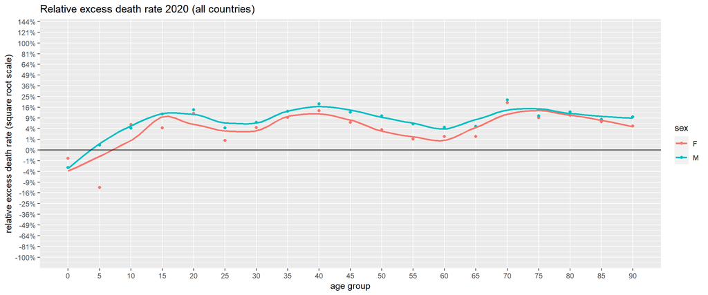

The following graphs shows the days of life that have been lost, in average for each age group and sex, in 2020, compared to expectations based on demographic projections. You can see that for all age groups, the loss of life expectancy is shorter than the duration of the lockdowns.

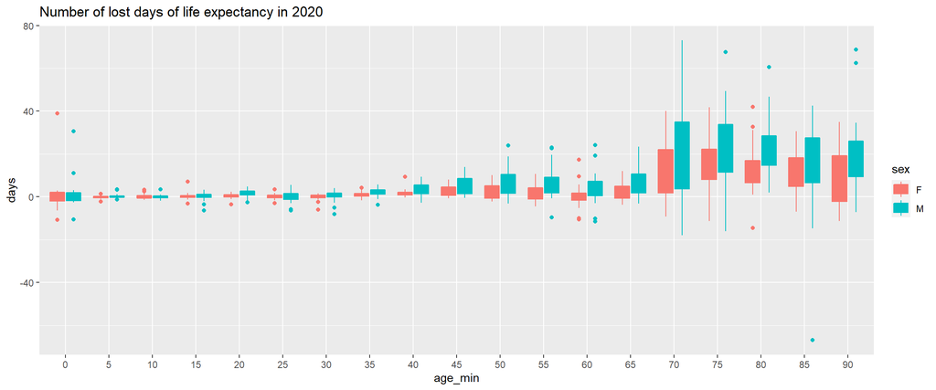

Note that there are great differences between countries regarding the mortality of young age groups. The following graphs shows the correlation between excess mortality over 65 and excess mortality under 65.

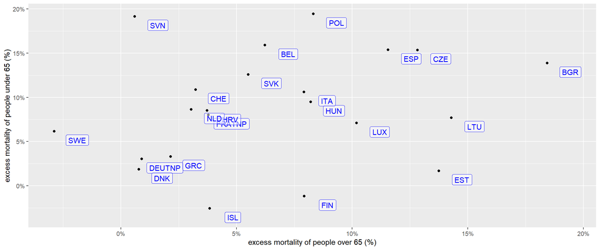

The correlation between these two series in not significant:

```
##
## Call:
## lm(formula = all_youth_mortality$under_65 ~ all_youth_mortality$over_65)
##
## Residuals:
##       Min        1Q    Median        3Q       Max
## -0.107007 -0.040434  0.002924  0.037278  0.118677
##
## Coefficients:
##                             Estimate Std. Error t value Pr(>|t|)
## (Intercept)                  0.07122    0.02120   3.360  0.00312 **
## all_youth_mortality$over_65  0.26489    0.25307   1.047  0.30772
## ---
## Signif. codes:  0 '***' 0.001 '**' 0.01 '*' 0.05 '.' 0.1 ' ' 1
##
## Residual standard error: 0.06182 on 20 degrees of freedom
## Multiple R-squared:  0.05194,    Adjusted R-squared:  0.004532
## F-statistic: 1.096 on 1 and 20 DF,  p-value: 0.3077
```

## Did governement restrictions help?

**No, there is no indication that government restrictions on freedom of movement and association helped reducing mortality.**

The principal response of European governments was to restrict the freedom of movement and association of the population. This is called “containment health” by the [Oxford Covid-19 Government Response Tracker](https://github.com/OxCGRT/covid-policy-tracker). Government justified their action by saying that mortality can be reduced by restricting the mobility and number of contacts of people.

How did that turn out? Quite the opposite actually.

The following graphs shows the correlation between the relative excess mortality in a country and the containment health index.

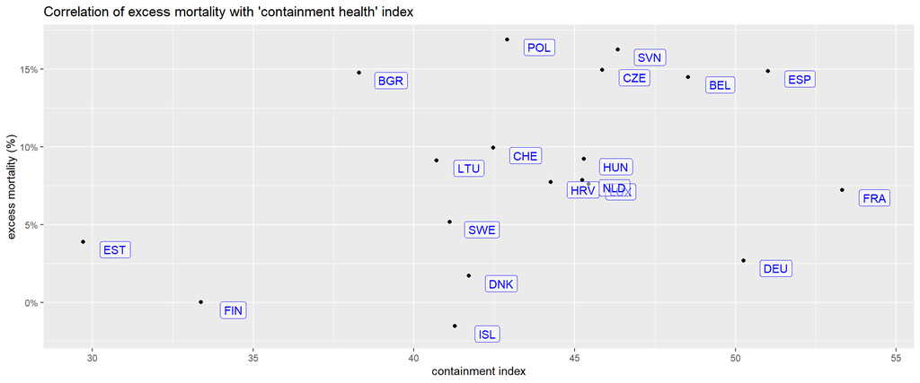

You can see that the correlation is *weak* but is *positive*: the more restrictions the government imposed, the more people died, or inversely (correlation is not causality). The correlation is not significant (80%), but what is significant is that there_no_ indication that government policies were useful in reducing the mortality.

Justifying restrictions on freedom based on comparisons between countries is a false argument. Data shows the opposite.

## Did people died less when they staid at home?

As you may know, Google tracks the location and movements of anybody using Android phones or other Google apps. Google know if people staid at home, commuted to work, spent time in nature, or other. Google makes aggregate data available for researches.

From this data, can we conclude that staying at home helped? The answer is simply *no*:

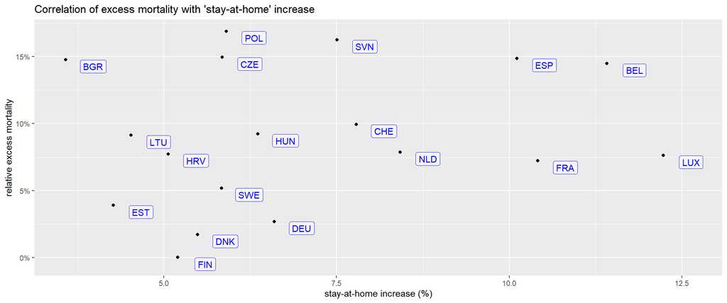

Curious about the details of the correlation?

```
##
## Call:
## lm(formula = mobility_death_correlation$death_increase ~ mobility_death_correlation$residential)
##
## Residuals:
##      Min       1Q   Median       3Q      Max
## -0.08347 -0.03656 -0.00098  0.04184  0.08243
##
## Coefficients:
##                                        Estimate Std. Error t value Pr(>|t|)
## (Intercept)                            0.061510   0.037716   1.631    0.122
## mobility_death_correlation$residential 0.004247   0.005061   0.839    0.414
##
## Residual standard error: 0.0531 on 16 degrees of freedom
## Multiple R-squared:  0.04216,    Adjusted R-squared:  -0.0177
## F-statistic: 0.7043 on 1 and 16 DF,  p-value: 0.4137
```

## Did those who went to nature die less?

**Yes, people who spent more time in nature died less.**

This is the most significant and surprising correlation found between Google mobility data and excess mortality.

[figure not shown]

How significant is this? Very! More than 99.9%. This is actually the highest correlation I have found in data.

```
##
## Call:
## lm(formula = mobility_death_correlation$death_increase ~ mobility_death_correlation$parks)
##
## Residuals:
##       Min        1Q    Median        3Q       Max
## -0.060899 -0.023933  0.004608  0.024315  0.065730
##
## Coefficients:
##                                    Estimate Std. Error t value Pr(>|t|)
## (Intercept)                       0.1625297  0.0183592   8.853 2.42e-07 ***
## mobility_death_correlation$parks -0.0013407  0.0003056  -4.387 0.000531 ***
## ---
## Signif. codes:  0 '***' 0.001 '**' 0.01 '*' 0.05 '.' 0.1 ' ' 1
##
## Residual standard error: 0.03699 on 15 degrees of freedom
##   (1 observation deleted due to missingness)
## Multiple R-squared:  0.562,  Adjusted R-squared:  0.5328
## F-statistic: 19.25 on 1 and 15 DF,  p-value: 0.0005306
```

The more populations went to parks, gardens and nature, and the less they died.

## Did people die because of COVID-19 or because of lockdowns?

**Old people probably died from COVID-19, young people probably from lockdowns.**

People of all age groups died prematurely in 2020, except maybe early infancy. How is mortality in different age groups correlated to official COVID-19 mortality?

The following correlation graphs shows that only the mortality of people aged over 65 is correlated to COVID-19 mortality. Mortality of lower age groups has no significant correlation with COVID-19 mortality, although these age groups have suffered an equivalent increase of relative mortality than the older age groups.

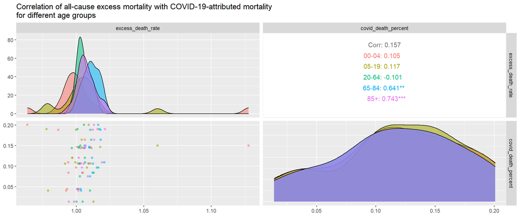

## When was the last time there was such mortality?

**The mortality of 2020 was typical of the year 2010.**

If as many people died in 2010 than in 2020, given the same population structure, 2010 would have been a normal year. The reason why 2020 is perceived as an exceptionally bad year is due to the aging of the population and the constant decrease of mortality in the last 10 years.

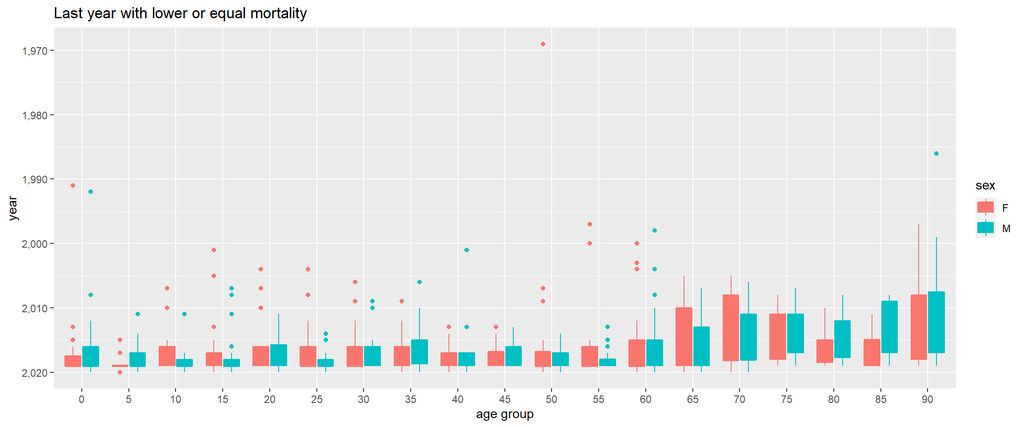

## When is the last time that so many people died prematurely?

**The excess mortality of 2020 was typical of the 1970s.**

If as many people died in 1975 than in 2020, compared to the year before, and given the same population structure, 1975 would have been a normal year.

The comparison of COVID-19 to the Spanish flu is unjustified, and there is no data proving which part of excess mortality is due to the virus itself, and which part to the governmental and media response to the epidemic.

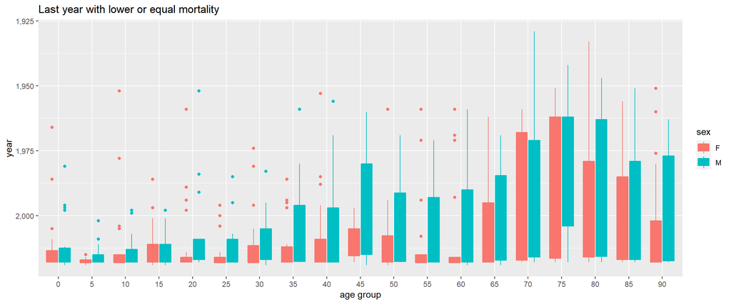

## Summary

The most significant correlation and the biggest surprise is the correlation between the time people in nature and the mortality. It suggests governments should strongly encourage people to go out, where some have restricted that right.

This article also shows that the perception of COVID-19 being a one-in-a-century disaster is unjustified, because 2020 is similar to 2010 from the point of view of mortality, and to 1970 from the point of view of excess mortality.

Finally, this article shows that the claim that the principal victims of the “2020” phenomenon are the 80+ is inaccurate. Almost all age groups have been affected, but there youth mortality seems due to lockdowns than to the virus. To a certain extent, the claim that the youth was sacrificed for the elders, from a mortality point of view, seems justified.